# P5_EDA_nb

Hack U Winter 2017: Data Science in the Wild

Scott Tse 3/14/17

This project summary describe's my work with machine learning algorithms to identify fraud in the Enron email data set, which is probably the largest publicly available email data set available.

The email dataset, which originally was comprised of around 500K emails is availabe [here](https://www.cs.cmu.edu/~./enron/). It is made up of emails from mostly Sr. Management at Enron and was used during the DOJ investigation of Enron and key executives. In its current form, the emails have been cleaned by individuals at MIT and SRI, and some personal information has been redacted at requested of affected indivuduals.

The Enron scandal is one of the largest corporate scandals ever to take place in the US. At its peak, it was a diversifed energy, commodities and services company, dealing in natural gas, energy trading and even broadband services. By revenue, it was at one point the 7th largest company in the US and a stock market darling througout the late 1990s. In the end, Enron was undone by its fraudulent accounting practices which were revealed to be misleading and largely falsified. The scandal not only caused the bankrupty and destruction of Enron but also that of the veritable accounting firm, Arthur Anderson, which had been in existance for almost 90 years. A detailed history of the scandal an be found on [Wikipedia](https://en.wikipedia.org/wiki/Enron_scandal)

In this machine learning exercise, I attempt to create a classification model that can predict 'persons of interest' (POIs) from various features. For the purposes of this project, a POI is a person who was prosecuted, or reached a plea deal in exchange for reduced sentence. I was introduced to this dataset while taking Udactiy's Data Analyst nanodegree.

Data was preprocessed into a python dictionary where the keys were the names of the individuals and the values were also dictionaries of several features. The features were of 3 main types: financial features, email features, and POI labels:

**financial features:** ['salary', 'deferral_payments', 'total_payments', 'loan_advances', 'bonus', 'restricted_stock_deferred', 'deferred_income', 'total_stock_value', 'expenses', 'exercised_stock_options', 'other', 'long_term_incentive', 'restricted_stock', 'director_fees'] (all units are in US dollars)

**email features:** ['to_messages', 'email_address', 'from_poi_to_this_person', 'from_messages', 'from_this_person_to_poi', 'shared_receipt_with_poi'] (units are generally number of emails messages; notable exception is ‘email_address’, which is a text string)

**POI label:** [‘poi’] (boolean, represented as integer)

```python
# EDA
import sys
import pickle
sys.path.append("../tools/")

from feature_format import featureFormat, targetFeatureSplit
from tester import dump_classifier_and_data

with open("final_project_dataset.pkl", "r") as data_file:
    data_dict1 = pickle.load(data_file)
```

```python
# how many people in the dataset given that the dictionary data_dict has names as keys
len(data_dict1)
```

```
146
```

```python
# look at one key entry to see data structure:
data_dict1['SKILLING JEFFREY K']
```

```
{'bonus': 5600000,
 'deferral_payments': 'NaN',
 'deferred_income': 'NaN',
 'director_fees': 'NaN',
 'email_address': 'jeff.skilling@enron.com',
 'exercised_stock_options': 19250000,
 'expenses': 29336,
 'from_messages': 108,
 'from_poi_to_this_person': 88,
 'from_this_person_to_poi': 30,
 'loan_advances': 'NaN',
 'long_term_incentive': 1920000,
 'other': 22122,
 'poi': True,
 'restricted_stock': 6843672,
 'restricted_stock_deferred': 'NaN',
 'salary': 1111258,
 'shared_receipt_with_poi': 2042,
 'to_messages': 3627,
 'total_payments': 8682716,
 'total_stock_value': 26093672}
```

```python
# how many of the 146 individuals in the dataset are POIs?
sum([1 for person in data_dict1 if data_dict1[person]['poi'] == True])
```

```
18
```

```python
# let's take a look at the salaries
import pandas as pd

salaries = {}
for person in data_dict1:
    salaries[person] = data_dict1[person]['salary']
salaries
```

```
{'ALLEN PHILLIP K': 201955,
 'BADUM JAMES P': 'NaN',
 'BANNANTINE JAMES M': 477,
 'BAXTER JOHN C': 267102,
 'BAY FRANKLIN R': 239671,
 'BAZELIDES PHILIP J': 80818,
 'BECK SALLY W': 231330,
 'BELDEN TIMOTHY N': 213999,
 'BELFER ROBERT': 'NaN',
 'BERBERIAN DAVID': 216582,
 'BERGSIEKER RICHARD P': 187922,
 'BHATNAGAR SANJAY': 'NaN',
 'BIBI PHILIPPE A': 213625,
 'BLACHMAN JEREMY M': 248546,
 'BLAKE JR. NORMAN P': 'NaN',
 'BOWEN JR RAYMOND M': 278601,
 'BROWN MICHAEL': 'NaN',
 'BUCHANAN HAROLD G': 248017,
 'BUTTS ROBERT H': 261516,
 'BUY RICHARD B': 330546,
 'CALGER CHRISTOPHER F': 240189,
 'CARTER REBECCA C': 261809,
 'CAUSEY RICHARD A': 415189,
 'CHAN RONNIE': 'NaN',
 'CHRISTODOULOU DIOMEDES': 'NaN',
 'CLINE KENNETH W': 'NaN',
 'COLWELL WESLEY': 288542,
 'CORDES WILLIAM R': 'NaN',
 'COX DAVID': 314288,
 'CUMBERLAND MICHAEL S': 184899,
 'DEFFNER JOSEPH M': 206121,
 'DELAINEY DAVID W': 365163,
 'DERRICK JR. JAMES V': 492375,
 'DETMERING TIMOTHY J': 210500,
 'DIETRICH JANET R': 250100,
 'DIMICHELE RICHARD G': 262788,
 'DODSON KEITH': 221003,
 'DONAHUE JR JEFFREY M': 278601,
 'DUNCAN JOHN H': 'NaN',
 'DURAN WILLIAM D': 210692,
```

[output cut: 91 more lines]

```
 'UMANOFF ADAM S': 288589,
 'URQUHART JOHN A': 'NaN',
 'WAKEHAM JOHN': 'NaN',
 'WALLS JR ROBERT H': 357091,
 'WALTERS GARETH W': 'NaN',
 'WASAFF GEORGE': 259996,
 'WESTFAHL RICHARD K': 63744,
 'WHALEY DAVID A': 'NaN',
 'WHALLEY LAWRENCE G': 510364,
 'WHITE JR THOMAS E': 317543,
 'WINOKUR JR. HERBERT S': 'NaN',
 'WODRASKA JOHN': 'NaN',
 'WROBEL BRUCE': 'NaN',
 'YEAGER F SCOTT': 158403,
 'YEAP SOON': 'NaN'}
```

```python
# I noticed many entries where salaries are NaN. Let's just look at these records and
null_salaries = {}
for person in data_dict1:
    if data_dict1[person]['salary'] == 'NaN':
        null_salaries[person] = data_dict1[person]['salary']

print len(null_salaries)
null_salaries
```

```
51
```

```
{'BADUM JAMES P': 'NaN',
 'BELFER ROBERT': 'NaN',
 'BHATNAGAR SANJAY': 'NaN',
 'BLAKE JR. NORMAN P': 'NaN',
 'BROWN MICHAEL': 'NaN',
 'CHAN RONNIE': 'NaN',
 'CHRISTODOULOU DIOMEDES': 'NaN',
 'CLINE KENNETH W': 'NaN',
 'CORDES WILLIAM R': 'NaN',
 'DUNCAN JOHN H': 'NaN',
 'FOWLER PEGGY': 'NaN',
 'FOY JOE': 'NaN',
 'FUGH JOHN L': 'NaN',
 'GATHMANN WILLIAM D': 'NaN',
 'GIBBS DANA R': 'NaN',
 'GILLIS JOHN': 'NaN',
 'GRAMM WENDY L': 'NaN',
 'HAUG DAVID L': 'NaN',
 'HAYES ROBERT E': 'NaN',
 'HAYSLETT RODERICK J': 'NaN',
 'HIRKO JOSEPH': 'NaN',
 'HORTON STANLEY C': 'NaN',
 'HUGHES JAMES A': 'NaN',
 'JAEDICKE ROBERT': 'NaN',
 'LEMAISTRE CHARLES': 'NaN',
 'LEWIS RICHARD': 'NaN',
 'LOCKHART EUGENE E': 'NaN',
 'LOWRY CHARLES P': 'NaN',
 'MCCARTY DANNY J': 'NaN',
 'MCDONALD REBECCA': 'NaN',
 'MENDELSOHN JOHN': 'NaN',
 'MEYER JEROME J': 'NaN',
 'MEYER ROCKFORD G': 'NaN',
 'MORAN MICHAEL P': 'NaN',
 'NOLES JAMES L': 'NaN',
 'PEREIRA PAULO V. FERRAZ': 'NaN',
 'PIRO JIM': 'NaN',
 'POWERS WILLIAM': 'NaN',
 'PRENTICE JAMES': 'NaN',
 'SAVAGE FRANK': 'NaN',
 'SCRIMSHAW MATTHEW': 'NaN',
 'SHERRICK JEFFREY B': 'NaN',
 'THE TRAVEL AGENCY IN THE PARK': 'NaN',
 'URQUHART JOHN A': 'NaN',
 'WAKEHAM JOHN': 'NaN',
 'WALTERS GARETH W': 'NaN',
 'WHALEY DAVID A': 'NaN',
 'WINOKUR JR. HERBERT S': 'NaN',
 'WODRASKA JOHN': 'NaN',
 'WROBEL BRUCE': 'NaN',
 'YEAP SOON': 'NaN'}
```

```python
# look at 'THE TRAVEL AGENCY IN THE PARK'. It's obviously not an actual individual, but let's look at its values.
print data_dict1['THE TRAVEL AGENCY IN THE PARK']
```

```
{'salary': 'NaN', 'to_messages': 'NaN', 'deferral_payments': 'NaN', 'total_payments': 362096, 'exercised_stock_options': 'NaN', 'bonus': 'NaN', 'restricted_stock': 'NaN', 'shared_receipt_with_poi': 'NaN', 'restricted_stock_deferred': 'NaN', 'total_stock_value': 'NaN', 'expenses': 'NaN', 'loan_advanc…
```

```python
# create pandas dataframe for easy plotting

df2 = pd.DataFrame.from_dict(data = data_dict1, orient='index')
df2.info()
```

```
<class 'pandas.core.frame.DataFrame'>
Index: 146 entries, ALLEN PHILLIP K to YEAP SOON
Data columns (total 21 columns):
salary                       146 non-null object
to_messages                  146 non-null object
deferral_payments            146 non-null object
total_payments               146 non-null object
exercised_stock_options      146 non-null object
bonus                        146 non-null object
restricted_stock             146 non-null object
shared_receipt_with_poi      146 non-null object
restricted_stock_deferred    146 non-null object
total_stock_value            146 non-null object
expenses                     146 non-null object
loan_advances                146 non-null object
from_messages                146 non-null object
other                        146 non-null object
from_this_person_to_poi      146 non-null object
poi                          146 non-null bool
director_fees                146 non-null object
deferred_income              146 non-null object
long_term_incentive          146 non-null object
email_address                146 non-null object
from_poi_to_this_person      146 non-null object
dtypes: bool(1), object(20)
memory usage: 24.1+ KB
```

```python
# correct datatypes
text_cols = ['email_address', 'poi']

for column in df2:
    if column not in text_cols:
        df2[column] = pd.to_numeric(df2[column], errors = 'coerce')

df2.info()
```

```
<class 'pandas.core.frame.DataFrame'>
Index: 146 entries, ALLEN PHILLIP K to YEAP SOON
Data columns (total 21 columns):
salary                       95 non-null float64
to_messages                  86 non-null float64
deferral_payments            39 non-null float64
total_payments               125 non-null float64
exercised_stock_options      102 non-null float64
bonus                        82 non-null float64
restricted_stock             110 non-null float64
shared_receipt_with_poi      86 non-null float64
restricted_stock_deferred    18 non-null float64
total_stock_value            126 non-null float64
expenses                     95 non-null float64
loan_advances                4 non-null float64
from_messages                86 non-null float64
other                        93 non-null float64
from_this_person_to_poi      86 non-null float64
poi                          146 non-null bool
director_fees                17 non-null float64
deferred_income              49 non-null float64
long_term_incentive          66 non-null float64
email_address                146 non-null object
from_poi_to_this_person      86 non-null float64
dtypes: bool(1), float64(19), object(1)
memory usage: 24.1+ KB
```

```python
df2.count()/len(df2)
```

```
salary                       0.650685
to_messages                  0.589041
deferral_payments            0.267123
total_payments               0.856164
exercised_stock_options      0.698630
bonus                        0.561644
restricted_stock             0.753425
shared_receipt_with_poi      0.589041
restricted_stock_deferred    0.123288
total_stock_value            0.863014
expenses                     0.650685
loan_advances                0.027397
from_messages                0.589041
other                        0.636986
from_this_person_to_poi      0.589041
poi                          1.000000
director_fees                0.116438
deferred_income              0.335616
long_term_incentive          0.452055
email_address                1.000000
from_poi_to_this_person      0.589041
dtype: float64
```

There are 20 features (poi is not included since that is the target response variable). Looking at the .info() and .count() method objects above, we can see that there is assymetry in the "completeness" of each feature. Several features have very few non null values as a % of the total.

```python
# import libraries for plotting

import matplotlib.pyplot as plt
import seaborn as sns
import numpy as np
%matplotlib inline
```

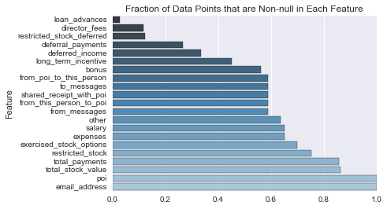

```python
#sns.barplot(x = df2.count()/144[0], y =df2.count()/144[1], data=df2.count()/144)
null_counts = pd.DataFrame(df2.count()/len(df2), columns = ['nonnull_count'])
null_counts = null_counts.reset_index() # make the default index of 1 dim df a column again
null_counts = null_counts.sort_values('nonnull_count') # sort by null_count
ax = sns.barplot(x = 'nonnull_count',y = 'index', data = null_counts, palette="Blues_d")
plt.title('Fraction of Data Points that are Non-null in Each Feature')
ax.set(xlabel = "", ylabel = 'Feature')
```

The barplot above helps clarify which features have many null values. We can see that features such as 'loan_advances', director_fees, and restricted_stock_deferred have very few non null values (<20%). We may consider these and other features that are dominated by null values as candidates to be removed from modeling.

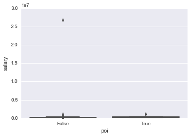

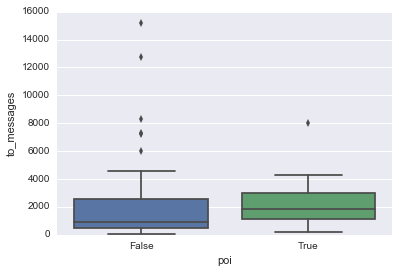

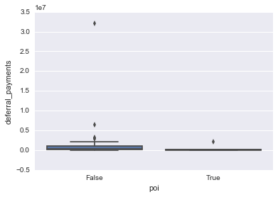

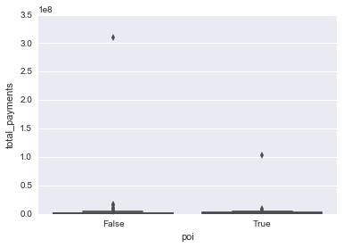

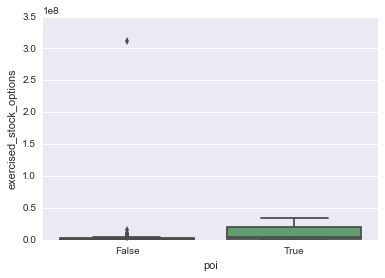

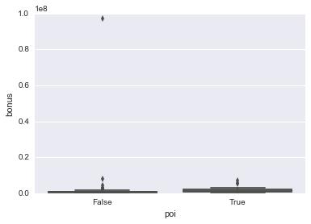

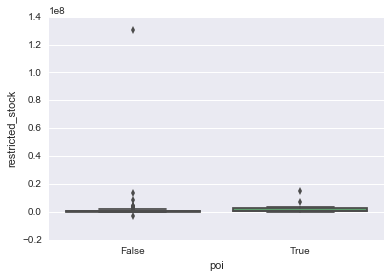

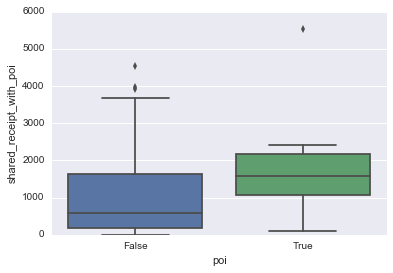

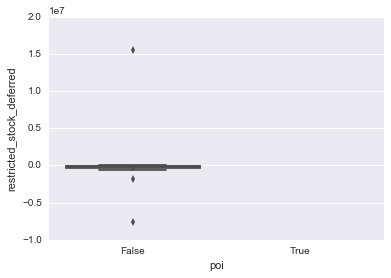

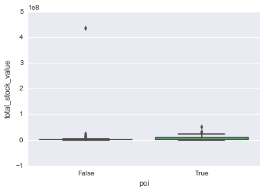

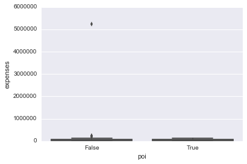

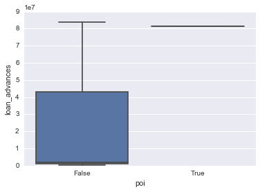

[7 more figures not shown]

```python
# make some boxplots to see what each variable looks like when split on POI and non POI

dont_plot = ['email_address', 'poi']

for column in df2:
    if column not in dont_plot:
        plt.figure()
        sns.boxplot(x = 'poi', y = column,
               data = df2)
```

**Outlier Removal**

In many of the financial features we can see an obvious outlier which we can see created by the spreadsheet artifact entry 'TOTAL'. We remove this outlier since it's a aggregated value and not an individual. Including it in any modeling will definitely bias the predictions incorrectly. In addition, since 'THE TRAVEL AGENCY IN THE PARK' is not an actual individual, and most of its values are 'NaN' I will remove it from the dataset.

One can also see a large outlier in 'total_payments' which is the ~$103M figure for Ken Lay. Since there are only 18 POIs removing one is a big deal so I will leave his data in the dataset for now, but we might test removing him later to see how that affects model diagnostics.

```python
#data_dict1.pop('TOTAL')
#data_dict1.pop('THE TRAVEL AGENCY IN THE PARK')
df2 = df2.drop(['TOTAL','THE TRAVEL AGENCY IN THE PARK'])
```

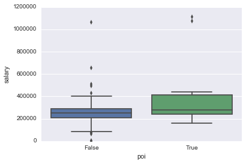

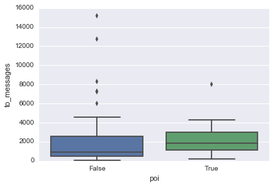

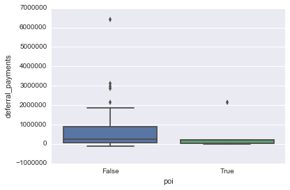

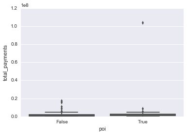

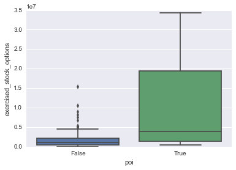

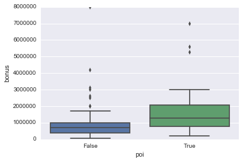

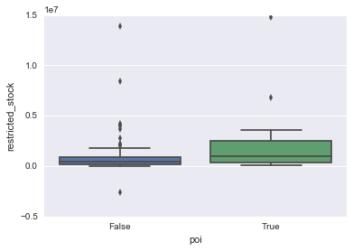

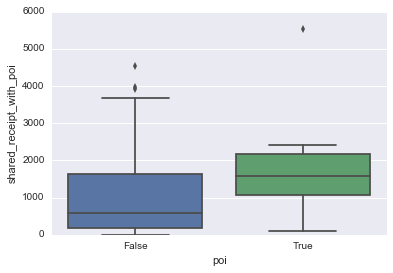

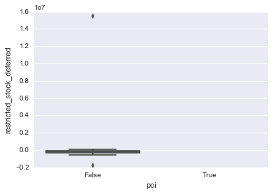

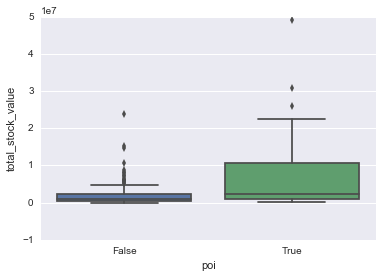

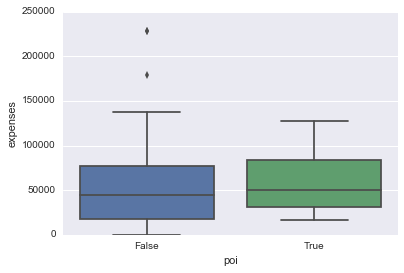

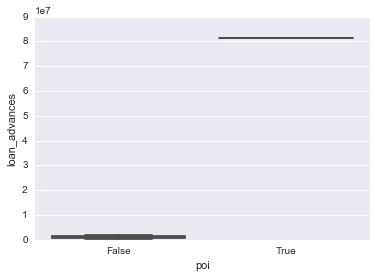

[7 more figures not shown]

```python
# replot boxplots with outliers removed

dont_plot = ['email_address', 'poi']

for column in df2:
    if column not in dont_plot:
        plt.figure()
        sns.boxplot(x = 'poi', y = column,
               data = df2)
```

```
(0, 20000000)
```

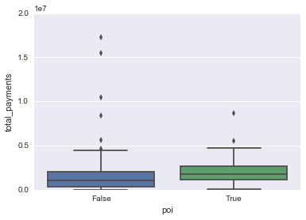

```python
# closer looks
sns.boxplot(x = 'poi', y = 'total_payments',
               data = df2)
plt.ylim(0, 20000000)
```

Looking at the boxplots above, there are several factors that visually appear to have some relationship with whether an indivudual is a POI. exercised_stock_options, bonus, shared_receipt_with_poi, total_stock_value, director_fees, and exercised_stock_options are all examples. Also interestingly, no POIs had any values for director_fees.

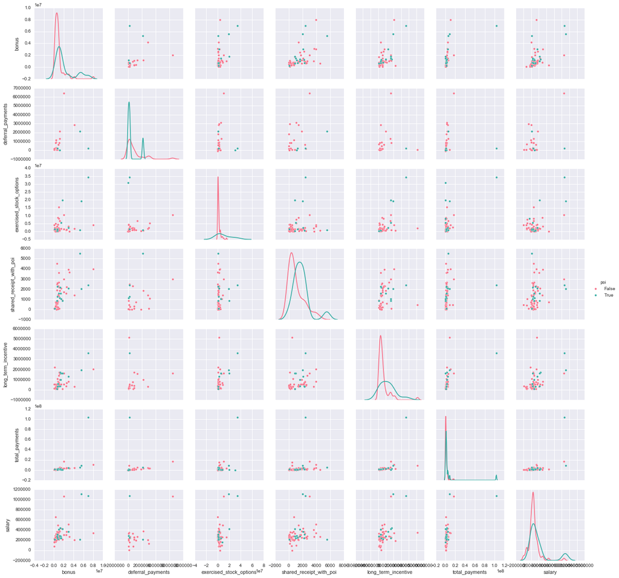

```python
# explore pairplots of financial variables with hue split on 'poi' (red for 'not poi', green for 'poi')
sns.pairplot(df2, hue = 'poi', diag_kind='kde', palette="husl",
             vars = ['bonus','deferral_payments','exercised_stock_options',
                    'shared_receipt_with_poi','long_term_incentive',
                    'total_payments','salary'])
```